# Lab7

Anya Conti

April 13, 2017

```r
#imports library for graphing for question 2
library(ggplot2)
```

**Question 1**

For each of the importance functions given, here are the calculated CDFs and inverses of the CDFs.

$f_1 = 1$  
$F_1 = x$  
$F_1 ^{-1} = x$

$f_2 = e^{-x}$  
$F_2 = 1-e^{-x}$  
$F_2 ^{-1} = -ln(1-x)$

$f_3 = \frac{1}{\pi}\frac{1}{1+x^2}$  
$F_3 = \frac{1}{\pi}arctan(x)$  
$F_3^{-1} = tan(\pi(x-0.5))$

$f_4 = \frac{e^{-x}}{1-e^{-1}}$  
$F_4 = \frac{1-e^{-x}}{1-e^{-1}}$  
$F_4 ^{-1} = -ln(1-x+xe^{-1})$

$f_5 = \frac{4}{\pi}\frac{1}{1+x^2}$  
$F_5 = \frac{4}{\pi}arctan(x)$  
$F_5^{-1} = tan(0.25*\pi*x)$

Then we simulate data from a uniform distribution, stored as x. This data is then plugged into the inverse CDFs of each importance function to simulate data from that particular distribution.

```r
#Randomly generates 10000 numbers from a uniform distribution between 0 and 1
x <- runif(10000)

#Plugs the uniformly distributed values into the inverse CDF's of the importance functions which simulate data from those particular distributions
x1 <- x
x2 <- -log(1-x)
x3 <- tan(pi*(x-0.5))
x4 <- -log(1-x+x*exp(-1))
x5 <- tan(0.25*pi*x)
```

Simulates the orignal integral using the importance function, and the fact that this is equivalent to taking the expectation of the integrand divided by the importance funtion, given a distribution of the importance function. The estimations are then stored and shown below.

```r
#Creates a data frame with 5 rows (1 for each importance function) and 3 columns: one with the number of each importance function, one for the mean of the simulated data that acts as the estimate, and one as the standard deviation of the simulated data
result <- data.frame("f" = seq(1:5), "mean" = rep(0,5), "sd" = rep(0,5))


#For each one, plugs the data distributed along the importance function generated above (x1,...,x5) into the rest of the integral (what we're taking the expectation of given a distribution of the importance function) to simulate the expectation, and thus the overall integral as well.  Takes the mean and standard deviation of these to compare, and stores them in the result data frame.
y1 <- rep(NA,10000)
for(i in 1:10000){
  if(x1[i] < 0 | x1[i] > 1){
    y1[i] <- 0
  }
  else{
    y1[i] <- exp(-x1[i])/(1+x1[i]^2)
  }
}
result[1,2] <- mean(y1)
result[1,3] <- sd(y1)/sqrt(10000)




y2 <- rep(NA,10000)
for(i in 1:10000){
  if(x2[i] < 0 | x2[i] > 1){
    y2[i] <- 0
  }
  else{
    y2[i] <- 1/(1+x2[i]^2)
  }
}
result[2,2] <- mean(y2)
result[2,3] <- sd(y2)/sqrt(10000)


y3 <- rep(NA,10000)
for(i in 1:10000){
  if(x3[i] < 0 | x3[i] > 1){
    y3[i] <- 0
  }
  else{
    y3[i] <- pi*exp(-(x3[i]))
  }
}
result[3,2] <- mean(y3)
result[3,3] <- sd(y3)/sqrt(10000)




y4 <- rep(NA,10000)
for(i in 1:10000){
  if(x4[i] < 0 | x4[i] > 1){
    y3[i] <- 0
  }
  else{
    y4[i] <- (1-exp(-1))/(1+x4[i]^2)
  }
}
result[4,2] <- mean(y4)
result[4,3] <- sd(y4)/sqrt(10000)





y5 <- rep(NA,10000)
for(i in 1:10000){
  if(x5[i] < 0 | x5[i] > 1){
    y5[i] <- 0
  }
  else{
    y5[i] <- (pi/4)*exp(-(x5[i]))
  }
}
result[5,2] <- mean(y5)
result[5,3] <- sd(y5)/sqrt(10000)

result
```

```
##   f      mean           sd
## 1 1 0.5256262 0.0024481670
## 2 2 0.5281672 0.0041671713
## 3 3 0.5278463 0.0095569026
## 4 4 0.5252382 0.0009666368
## 5 5 0.5253306 0.0014106195
```

The best importance function (the one with the smallest standard deviation) is thus $f(x) = \frac{e^{-x}}{1-e^{-1}}$.

**Question 2**

Here are the numerical results (mean and standard deviation) for gamma functions with alpha values 1 through 15 used as the importance functions. Then just these 15 results are plotted below.

```r
#Creates a data frame to store the means and standard deviations of each simulation estimate
output <- data.frame("alpha" = seq(from=1, to =15, by = 1), "mean" = rep(0,length(seq(from=1, to =15, by = 1))), "sd" = rep(0,length(seq(from=1, to =15, by = 1))))

#Uses a loop to simulate data for each importance function using a gamma function with a value of alpha from 1 to 15, and stores the results of the mean and standard deviation in output (count just keeps track of which entry in the output it is)
count <- 1
for(i in seq(from=1, to =15, by = 1)){
  #Simulates data from a gamma distribution which a certain alpha level
  x <- rgamma(100000, i)
  #The two functions below both work the same way: Plug the data into the function we're taking the expectation of, given a distribution of the importance function.
  #temp <- ((x^(3-i))/(1+x+(x^2)))*(gamma(i)/gamma(3))
  temp <- (1/(1+x+(x^2)))*(dgamma(x,shape  = 3, rate = 1)/dgamma(x,shape = i, rate = 1))
  #Saves the mean and standard deviation to output
  output[count,2] <- mean(temp)
  output[count,3] <- sd(temp)/sqrt(100000)
  count <- count + 1
}

output
```

```
##    alpha       mean           sd
## 1      1 0.13491448 3.604088e-04
## 2      2 0.13520882 9.263758e-05
## 3      3 0.13500950 4.005599e-04
## 4      4 0.13465710 1.181422e-03
## 5      5 0.13775679 4.112352e-03
## 6      6 0.12729490 5.234920e-03
## 7      7 0.11094890 7.265526e-03
## 8      8 0.11794331 1.356454e-02
## 9      9 0.10658171 3.187576e-02
## 10    10 0.08526003 2.493301e-02
## 11    11 0.09705277 4.706884e-02
## 12    12 0.04504117 1.151499e-02
## 13    13 0.04654960 2.826308e-02
## 14    14 0.02567191 1.263136e-02
## 15    15 0.03657391 2.865276e-02
```

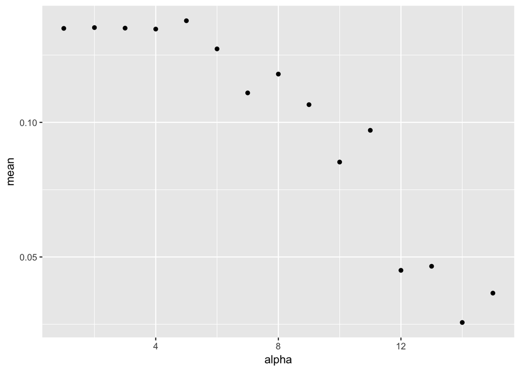

```r
#Plots just those particular estimates
ggplot(data = output) +
  geom_point(aes(x=alpha, y=mean))
```

Creates functions for the estimate, upper bound, and lower bound for graphing.

```r
#Creates a function for the estimate
est <- function(i){
  temp <- ((x^(3-i))/(1+x+(x^2)))*(gamma(i)/gamma(3))
  return(mean(temp))
}
#Creates a new one with sapply so the above function can be used on a whole vector
est_new<-function(i_v){sapply(i_v,est)}


#Creates a function for lower bound
estlb <- function(i){
  nums <- rgamma(100000,i)
  temp <- ((x^(3-i))/(1+x+(x^2)))*(gamma(i)/gamma(3))
  return(mean(temp)-sd(temp)*qnorm(.975))
}
#Creates a new one with sapply so the above function can be used on a whole vector
estlb_new <- function(i_v){sapply(i_v, estlb)}


#Creates a function for upper bound
estub <- function(i){
  nums <- rgamma(100000,i)
  temp <- ((x^(3-i))/(1+x+(x^2)))*(gamma(i)/gamma(3))
  return(mean(temp)+sd(temp)*qnorm(.975))
}
#Creates a new one with sapply so the above function can be used on a whole vector
estub_new <- function(i_v){sapply(i_v, estub)}
```

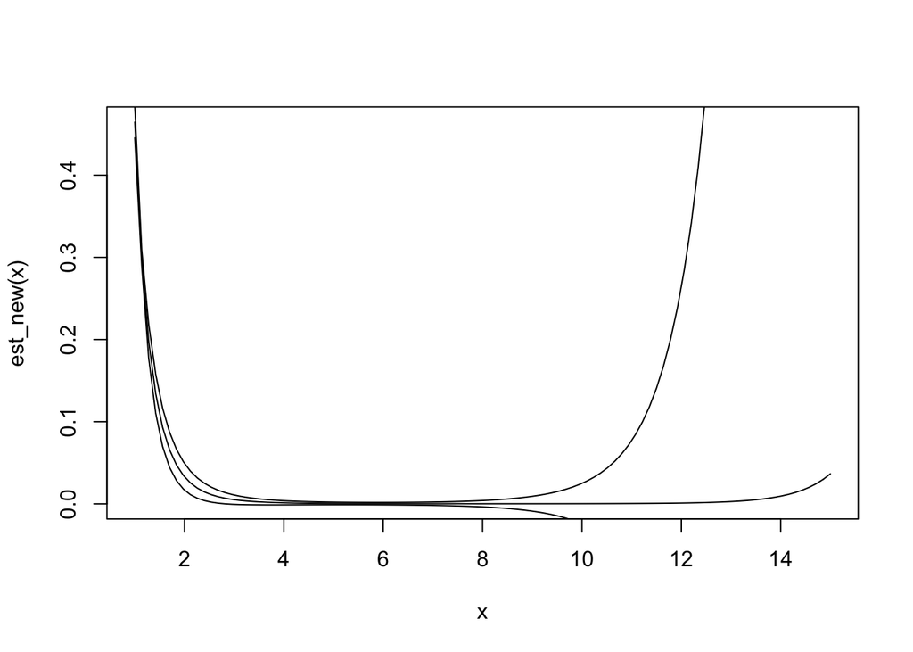

```r
#Plots the functions using curve()
curve(est_new, from = 1, to = 15)
curve(estlb_new, from = 1, to = 15, add = TRUE)
curve(estub_new, from = 1, to = 15, add = TRUE)
```

The importance function that seems to be the best is the gamma function with alpha = 2 (and beta = 1). This is the one with the lowest standard deviation.